# W13D3 - Buccarini Giacomo Es.3

Esercizio Abbiamo una lista di liste: mat = [[0, 1, 2, 3, 4], [5, 6, 7, 8, 9], [10, 11, 12, 13, 14]] Che tipo di struttura dati o matematica potrebbe rappresentare? # UNA MATRICE

Notare che tutte le liste "interne" sono della stessa dimensione Come facciamo per accedere ad un elemento in particolare?

```python
mat = [[0, 1, 2, 3, 4], [5, 6, 7, 8, 9], [10, 11, 12, 13, 14]]
mat[0][4]
```

```
4
```

Esercizio Importiamo il modulo math e proviamo a usare le funzioni .sin() .cos() .factorial() e la variabile .pi la riconoscete?

```python
import math
math.sin(10)
```

```
-0.5440211108893698
```

```python
math.cos(10)
```

```
-0.8390715290764524
```

```python
math.factorial(10)
```

```
3628800
```

Il pacchetto .pi è il PGreco

Esercizio Proviamo a eseguire math.degrees(math.pi) Qual è e cosa significa il risultato?

# Restituisce l'equivalente in gradi dell'angolo di 180 gradi, che corrisponde a π radianti.

Per saperne di più su questa funzione possiamo usare help(math.degrees)

```python
math.degrees(math.pi)
```

```
180.0
```

```python
help(math.pi)
```

[output not shown]

[output cut: 72 more lines]

[output not shown]

Esercizio L'azienda Object SpA ha creato una lista di quanti oggetti ha venduto ogni mese nell'ultimo anno: lst = [2000, 5500, 7200, 4320, 1280, 1900, 2500, 3900, 6410, 8150, 7100, 5350] trasformiamola in un array NumPy (casting): lst = np.array(lst) e rispondiamo alle domande del CEO della Object SpA: • qual è stata la vendita massima mensile? E quella minima? • quali sono le vendite mensili maggiori di 4999 oggetti? E quante ne sono? • quali sono le vendite minori di 3000 oggetti? 5 • in media quanti oggetti sono stati venduti al mese?

```python
import numpy as np
lst = [2000, 5500, 7200, 4320, 1280, 1900, 2500, 3900, 6410, 8150, 7100, 5350]
lst = np.array(lst)

print(max(lst))

lst.max()
```

```
8150
```

```
8150
```

```python
lst.size
```

```
12
```

```python
lst.min()
```

```
1280
```

```python
contatore = 0
vendite_maggiori = []
for vendita in lst:
    if vendita > 4999:
        vendite_maggiori.append(vendita)
        contatore+=1
print("Le vendite sono:", vendite_maggiori, "e sono", contatore)
```

```
Le vendite sono: [5500, 7200, 6410, 8150, 7100, 5350] e sono 6
```

```python
len(vendite_maggiori)
```

```
6
```

```python
filtro = lst > 4999
fil = lst < 3000
print("Le vendite maggiori di 4999 sono", lst[filtro])
print ("Le vendite minori di 3000 sono", lst[fil])
```

```
Le vendite maggiori di 4999 sono [5500 7200 6410 8150 7100 5350]
Le vendite minori di 3000 sono [2000 1280 1900 2500]
```

```python
lst[lst < 3000]
```

```
array([2000, 1280, 1900, 2500])
```

```python
lst.mean() #media oggetti venduti
```

```
4634.166666666667
```

Esercizio Consideriamo il seguente dizionario: fatturati_dict = {1997: 12_000, 1998: 15_000, 1999: 20_000, 2000: 23_000, 2001: 25_000, 2002: 17_000, 2003: 14_000, 2004: 21_000} Consideriamo ora la seguente Series: fatturati_series = pd.Series([12_000, 15_000, 20_000, 23_000, 25_000, 17_000, 14_000, 21_000], index=range(1997, 2005)) Possiamo accedere alle stesse informazioni nello stesso modo: fatturati_dict[1997] fatturati_series[1997] Dunque qual è la differenza tra i due tipi di dato? Cosa potremmo fare con la Series che non possiamo fare con il dizionario?

```python
import pandas as pd
fatturati_dict = {1997: 12_000, 1998: 15_000, 1999: 20_000, 2000: 23_000, 2001: 25_000, 2002: 17_000, 2003: 14_000, 2004: 21_000}
fatturati_series = pd.Series ([12_000, 15_000, 20_000, 23_000, 25_000, 17_000, 14_000, 21_000], index=range(1997, 2005))

fatturati_dict [1997]
fatturati_series [1997]

for anno in [2001, 2002, 2003, 2004]:
    print(fatturati_dict[anno])
```

```
25000
17000
14000
21000
```

```python
fatturati_series.mean()
```

```
18375.0
```

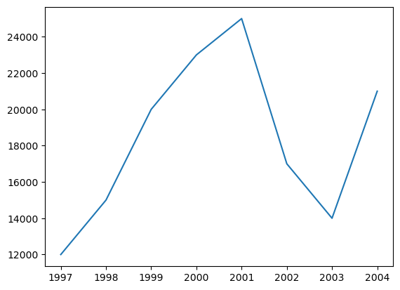

```python
fatturati_series.plot()
```

Esercizio L'azienda Object SpA ha un dataset con tutti gli stipendi dei dipendenti, memorizzato in un ndarray: import numpy as np stipendi = np.array( [100, 200, 300, 400, 500, 600, 700, 800, 900, 1000] ) L'azienda ci chiede di raddoppiare tutti gli stipendi; facciamolo in due modi: • con un ciclo for 7 • con il masking

```python
import numpy as np
stipendi = np.array( [100, 200, 300, 400, 500,  600, 700, 800, 900, 1000] )
stipendi_aumentati = []

for stipendio in stipendi:
    stipendi_aumentati.append(stipendio * 2)

print(stipendi_aumentati)
```

```
[200, 400, 600, 800, 1000, 1200, 1400, 1600, 1800, 2000]
```

```python
type(stipendi)
```

```
numpy.ndarray
```

```python
stipendi_aumentati = stipendi * 2
```

```python
stipendi_aumentati
```

```
array([ 200,  400,  600,  800, 1000, 1200, 1400, 1600, 1800, 2000])
```